# Preprocesamiento Dataset Properati

Juan Barriola y Sofía Perini

2 de Octubre de 2021

## Preparacion de los datos

```r
library(tidyverse)
library(corrr)
library(knitr)
library(kableExtra)
```

## Planteo del problema

Nuestro objetivo es crear un modelo lineal múltiple para explicar el precio de venta en dólares de las propiedades en Capital Federal reportadas por la empresa [Properati Argentina](https://www.properati.com.ar/).

Vamos a utilizar datos del 2019 para no incorporar comportamientos atípicos ocasionados por la pandemia del COVID-19.

### Lectura del dataset y su estructura

La estructura del dataset consiste en 24 variables (columnas) y 388.891 observaciones (filas). Entre las variables figuran distintos tipos (character, date, logical o double): id, fechas, ubicacion geográfica, pais, provincia, barrio, características como número de habitaciones, baños, superficie total o cubierta, precio, tipo de propiedad, operación, entre otras.

```r
# leo el archivo ar_properties
datos <- read_csv("../Fuentes/ar_properties.csv")
glimpse(datos)
```

```
Rows: 388,891
Columns: 24
$ id              <chr> "S0we3z3V2JpHUJreqQ2t/w==", "kMxcmAS8NvrynGBVbMOEaQ==", "C~
$ ad_type         <chr> "Propiedad", "Propiedad", "Propiedad", "Propiedad", "Propi~
$ start_date      <date> 2019-04-14, 2019-04-14, 2019-04-14, 2019-04-14, 2019-04-1~
$ end_date        <date> 2019-06-14, 2019-04-16, 9999-12-31, 9999-12-31, 2019-07-0~
$ created_on      <date> 2019-04-14, 2019-04-14, 2019-04-14, 2019-04-14, 2019-04-1~
$ lat             <dbl> -34.94331, -34.63181, NA, -34.65471, -34.65495, -32.93547,~
$ lon             <dbl> -54.92966, -58.42060, NA, -58.79089, -58.78712, -60.68398,~
$ l1              <chr> "Uruguay", "Argentina", "Argentina", "Argentina", "Argenti~
$ l2              <chr> "Maldonado", "Capital Federal", "Bs.As. G.B.A. Zona Norte"~
$ l3              <chr> "Punta del Este", "Boedo", NA, "Moreno", "Moreno", "Rosari~
$ l4              <chr> NA, NA, NA, "Moreno", "Moreno", NA, "Ituzaingó", NA, NA, N~
$ l5              <chr> NA, NA, NA, NA, NA, NA, NA, NA, NA, NA, NA, NA, NA, NA, NA~
$ l6              <lgl> NA, NA, NA, NA, NA, NA, NA, NA, NA, NA, NA, NA, NA, NA, NA~
$ rooms           <dbl> 2, NA, 2, 2, 2, 4, NA, 6, NA, NA, NA, NA, NA, NA, NA, NA, ~
$ bedrooms        <dbl> NA, NA, NA, NA, NA, NA, NA, NA, NA, NA, NA, NA, NA, NA, NA~
$ bathrooms       <dbl> 1, NA, 1, 2, 3, 1, 3, 3, NA, NA, NA, NA, NA, NA, NA, NA, N~
$ surface_total   <dbl> 45, NA, 200, 460, 660, NA, 70, NA, 1300, 405, 352, 373, 36~
$ surface_covered <dbl> 40, NA, NA, 100, 148, 89, 122, NA, NA, NA, NA, NA, NA, 2, ~
$ price           <dbl> 13000, 0, NA, NA, NA, NA, NA, NA, 0, NA, 0, NA, NA, NA, NA~
$ currency        <chr> "UYU", NA, NA, NA, NA, NA, NA, NA, NA, NA, NA, NA, NA, NA,~
$ price_period    <chr> "Mensual", "Mensual", NA, "Mensual", "Mensual", "Mensual",~
$ title           <chr> "Departamento - Roosevelt", "PH - Boedo", "Ituzaingo  1100~
$ property_type   <chr> "Departamento", "PH", "Casa", "Casa", "Casa", "Casa", "Cas~
$ operation_type  <chr> "Alquiler", "Venta", "Alquiler", "Venta", "Venta", "Venta"~
```

### b. Aplicando filtros

Se filtran aquellos registros que pertenecen a Argentina y Capital Federal, cuyo precio esta en dolares (USD), el tipo de propiedad corresponde a Departamento, PH o Casa, y el tipo de operacion sea Venta.

```r
# filtrando el dataset original
datos_filtrados <- datos %>%
                   # Me quedo con los que pertenecen a Argentina y Capital Federal
            filter(l1 == "Argentina",
                   l2 == "Capital Federal",
                   # cuyo precio este en dolares
                   currency == "USD",
                   # propiedad tipo Departamento, PH o Casa
                   property_type %in% c("Departamento", "PH", "Casa"),
                   # operaciones de venta
                   operation_type == "Venta")
```

Se obtuvo un dataset con 61905 observaciones y 24 variables.

```r
# chequeo si el filtro se refleja correctamente en mi nuevo dataset datos1b
head(datos_filtrados)
```

| id | ad_type | start_date | end_date | created_on | lat | lon | l1 | l2 | l3 | l4 | l5 | l6 | rooms | bedrooms | bathrooms | surface_total | surface_covered | price | currency | price_period | title | property_type | operation_type |
| --- | --- | --- | --- | --- | --- | --- | --- | --- | --- | --- | --- | --- | --- | --- | --- | --- | --- | --- | --- | --- | --- | --- | --- |
| oyj+f764ALCYodIqBvWAww== | Propiedad | 2019-04-14 | 2019-07-10 | 2019-04-14 | -34.65225 | -58.38556 | Argentina | Capital Federal | Barracas | NA | NA | NA | NA | NA | NA | 300 | 180 | 320000 | USD | Mensual | PH EN VENTA | PH | Venta |
| HdjpKrqdwYfH9YU1DKjltg== | Propiedad | 2019-04-14 | 2019-04-15 | 2019-04-14 | -34.62825 | -58.40652 | Argentina | Capital Federal | Boedo | NA | NA | NA | 6 | NA | 2 | 178 | 240 | 500000 | USD | Mensual | Casa - San Telmo | Casa | Venta |
| YwWE3rTb2+gmsBwjUHmAPQ== | Propiedad | 2019-04-14 | 2019-06-30 | 2019-04-14 | -34.59280 | -58.42093 | Argentina | Capital Federal | Palermo | NA | NA | NA | NA | NA | 2 | 240 | 157 | 350000 | USD | Mensual | CASA EN VENTA | Casa | Venta |
| 6AxnSWOhbIU8TUCqb+paBg== | Propiedad | 2019-04-14 | 9999-12-31 | 2019-04-14 | -34.56563 | -58.46513 | Argentina | Capital Federal | Belgrano | NA | NA | NA | 3 | NA | 4 | 157 | NA | 470000 | USD | NA | Mendoza 3200 - U$D 470.000 - Casa en Venta | Casa | Venta |
| U4fk+co3Rd8JDMot0pQI6Q== | Propiedad | 2019-04-14 | 2019-05-21 | 2019-04-14 | -34.62218 | -58.52272 | Argentina | Capital Federal | Versalles | NA | NA | NA | NA | NA | 1 | 140 | 110 | 155000 | USD | NA | Cortina 2000 - U$D 155.000 - Tipo casa PH en Venta | Casa | Venta |
| AfdcsqUSelai1ofCAq2B0Q== | Propiedad | 2019-04-14 | 9999-12-31 | 2019-04-14 | -34.63210 | -58.49768 | Argentina | Capital Federal | Velez Sarsfield | NA | NA | NA | 3 | NA | 2 | 95 | 69 | 199900 | USD | NA | Moron 4800 - U$D 199.900 - Tipo casa PH en Venta | Casa | Venta |

```r
# veo la dimension del nuevo dataset
dim(datos_filtrados) # 61905  24
```

```
[1] 61905    24
```

### Selección de variables de interés

Se seleccionan las variables *id*, *l3*, *rooms*, *bedrooms*, *bathrooms*, *surface_total*,*surface_covered*, *price* y *property_type*.

```r
#selecciono solo las variables de la consigna (9 de las 24)
datos_selec <- datos_filtrados %>%
            select(id, l3, rooms, bedrooms, bathrooms, surface_total, surface_covered, price, property_type)
# chequeo que la seleccion sea correcta
head(datos_selec)
```

| id | l3 | rooms | bedrooms | bathrooms | surface_total | surface_covered | price | property_type |
| --- | --- | --- | --- | --- | --- | --- | --- | --- |
| oyj+f764ALCYodIqBvWAww== | Barracas | NA | NA | NA | 300 | 180 | 320000 | PH |
| HdjpKrqdwYfH9YU1DKjltg== | Boedo | 6 | NA | 2 | 178 | 240 | 500000 | Casa |
| YwWE3rTb2+gmsBwjUHmAPQ== | Palermo | NA | NA | 2 | 240 | 157 | 350000 | Casa |
| 6AxnSWOhbIU8TUCqb+paBg== | Belgrano | 3 | NA | 4 | 157 | NA | 470000 | Casa |
| U4fk+co3Rd8JDMot0pQI6Q== | Versalles | NA | NA | 1 | 140 | 110 | 155000 | Casa |
| AfdcsqUSelai1ofCAq2B0Q== | Velez Sarsfield | 3 | NA | 2 | 95 | 69 | 199900 | Casa |

```r
# chequeo la dimension
glimpse(datos_selec)
```

```
Rows: 61,905
Columns: 9
$ id              <chr> "oyj+f764ALCYodIqBvWAww==", "HdjpKrqdwYfH9YU1DKjltg==", "Y~
$ l3              <chr> "Barracas", "Boedo", "Palermo", "Belgrano", "Versalles", "~
$ rooms           <dbl> NA, 6, NA, 3, NA, 3, 1, 1, 1, 1, 1, 1, 1, 1, 1, 1, 1, 1, 1~
$ bedrooms        <dbl> NA, NA, NA, NA, NA, NA, NA, NA, NA, NA, NA, NA, NA, NA, NA~
$ bathrooms       <dbl> NA, 2, 2, 4, 1, 2, 1, 1, 1, 1, 1, 1, 1, 1, 1, 1, 1, 1, 1, ~
$ surface_total   <dbl> 300, 178, 240, 157, 140, 95, 44, 40, 49, 40, 40, 40, 49, 4~
$ surface_covered <dbl> 180, 240, 157, NA, 110, 69, 38, 37, 44, 37, 37, 37, 44, 37~
$ price           <dbl> 320000, 500000, 350000, 470000, 155000, 199900, 147000, 92~
$ property_type   <chr> "PH", "Casa", "Casa", "Casa", "Casa", "Casa", "Departament~
```

## Analisis exploratorios

### Detección de valores unicos y faltantes

Calculando la cantidad de valores únicos y faltantes para cada una de estas variables, se observa que la variable bedrooms presenta gran cantidad de faltantes (mas de 25000, 40% de los datos), mientras que las variables id, precios y tipo de propiedad ninguno. El resto registran entre 300 y 5000 faltantes aprox., faltantes menores al 10% de los datos.

```r
# Armo una tabla por variable que indique cantidad de faltantes y valores unicos que existe en el dataset
tabla <- datos_selec %>% gather(.,
                                 key   = Variables,
                                 value = Valores) %>%
  group_by(Variables) %>%
  summarise(valores_unicos = n_distinct(Valores),
            valores_faltantes = sum(is.na(Valores)),
            porcentaje_faltantes = round(sum(is.na(Valores))/nrow(datos_selec)*100,2)) %>%
  arrange(desc(porcentaje_faltantes), valores_unicos) # ordenamos por porcentaje de faltantes y valores unicos
tabla
```

| Variables | valores_unicos | valores_faltantes | porcentaje_faltantes |
| --- | --- | --- | --- |
| bedrooms | 25 | 25298 | 40.87 |
| rooms | 24 | 5314 | 8.58 |
| surface_total | 671 | 3671 | 5.93 |
| bathrooms | 15 | 3196 | 5.16 |
| surface_covered | 573 | 2975 | 4.81 |
| l3 | 58 | 355 | 0.57 |
| property_type | 3 | 0 | 0.00 |
| price | 4095 | 0 | 0.00 |
| id | 61905 | 0 | 0.00 |

Graficando los valores faltantes.

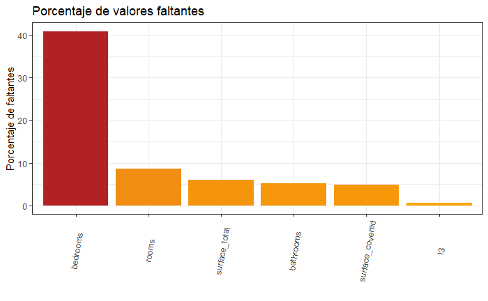

```r
tabla %>%
  filter(porcentaje_faltantes>0) %>%
  ggplot(., aes(x=reorder(Variables, -porcentaje_faltantes), y=porcentaje_faltantes, fill=porcentaje_faltantes)) +
  geom_bar(stat = "identity") +
  scale_fill_gradient(high = "firebrick", low = "orange") +
  scale_x_discrete(label = function(x) stringr::str_trunc(x, 18)) +
  theme_bw() +
  theme(axis.text.x = element_text(angle=80, vjust=0.5), legend.position = "none") +
  labs(title='Porcentaje de valores faltantes', y='Porcentaje de faltantes', x='')
```

### Matriz de correlación

Se calcularon los coeficientes de correlación de pearson y spearman para las variables numéricas. Dado que el análisis exploratorio (ver más abajo) confirmó la presencia de valores atípicos, se optó finalmente por utilizar el segundo ya que permite obtener resultados más robustos ante presencia de outliers.

En este sentido, se observa que todas las variables analizadas presentan correlación positiva. Las variables rooms y bedrooms presentan una asociación lineal positiva fuerte (0.97) así como también la superficie cubierta y total (0.96). Se destaca también una correlación positiva significativa entre el precio y la superficie total y cubierta (0.84), y entre la superficie y el número de habitaciones.

```r
# calculo matriz de correlacion para los registros completos (omitiendo faltantes) con ambos métodos
# pearson
# selecciono variables numericas para poder calcular la matriz de correlacion
matriz.correl.pe <- datos_selec %>% select(where(is.numeric)) %>%
 correlate(use = "complete.obs", method = "pearson") %>%
  shave() %>%
  fashion()
```

```
Correlation method: 'pearson'
Missing treated using: 'complete.obs'
```

```r
# spearman
matriz.correl.sp <- datos_selec %>% select(where(is.numeric)) %>%
 correlate(use = "complete.obs", method = "spearman")
```

```
Correlation method: 'spearman'
Missing treated using: 'complete.obs'
```

```r
# armo tabla de correlación con este último método
matriz.correl.sp %>%
  shave() %>%
  fashion()
```

| term | rooms | bedrooms | bathrooms | surface_total | surface_covered | price |
| --- | --- | --- | --- | --- | --- | --- |
| rooms |  |  |  |  |  |  |
| bedrooms | .97 |  |  |  |  |  |
| bathrooms | .64 | .63 |  |  |  |  |
| surface_total | .84 | .82 | .69 |  |  |  |
| surface_covered | .87 | .85 | .70 | .96 |  |  |
| price | .71 | .68 | .70 | .84 | .84 |  |

## Limpieza de datos

### Eliminación de la variable *bedrooms*

Se elimina la variable bedrooms por registrar gran presencia de faltantes (más de 25000) y correlación positiva fuerte con la variable rooms (0.97).

```r
# armo nuevo dataset excluyendo la variable bedroom
datos_limpios <- datos_selec %>%
  select(-c(bedrooms))
# chequeo que la haya eliminado
head(datos_limpios)
```

| id | l3 | rooms | bathrooms | surface_total | surface_covered | price | property_type |
| --- | --- | --- | --- | --- | --- | --- | --- |
| oyj+f764ALCYodIqBvWAww== | Barracas | NA | NA | 300 | 180 | 320000 | PH |
| HdjpKrqdwYfH9YU1DKjltg== | Boedo | 6 | 2 | 178 | 240 | 500000 | Casa |
| YwWE3rTb2+gmsBwjUHmAPQ== | Palermo | NA | 2 | 240 | 157 | 350000 | Casa |
| 6AxnSWOhbIU8TUCqb+paBg== | Belgrano | 3 | 4 | 157 | NA | 470000 | Casa |
| U4fk+co3Rd8JDMot0pQI6Q== | Versalles | NA | 1 | 140 | 110 | 155000 | Casa |
| AfdcsqUSelai1ofCAq2B0Q== | Velez Sarsfield | 3 | 2 | 95 | 69 | 199900 | Casa |

### Eliminación de registros con valores faltantes

Para evitar trabajar con imputación de datos, se decide eliminar los registros que presentan algún valor faltante. Esto representa alrededor del 15% del dataset

```r
# elimino los registros faltantes
datos_limpios <- datos_limpios %>% drop_na()
# chequeo no haya registros faltantes
head(datos_limpios)
```

| id | l3 | rooms | bathrooms | surface_total | surface_covered | price | property_type |
| --- | --- | --- | --- | --- | --- | --- | --- |
| HdjpKrqdwYfH9YU1DKjltg== | Boedo | 6 | 2 | 178 | 240 | 500000 | Casa |
| AfdcsqUSelai1ofCAq2B0Q== | Velez Sarsfield | 3 | 2 | 95 | 69 | 199900 | Casa |
| ESzybdH7YU2uIU1/kHtRGw== | Nuñez | 1 | 1 | 44 | 38 | 147000 | Departamento |
| r22OfzZ3kXooSPoE5HMuZQ== | Almagro | 1 | 1 | 40 | 37 | 92294 | Departamento |
| atZQXVtyfG7+OiX6gYY3lA== | Almagro | 1 | 1 | 49 | 44 | 115000 | Departamento |
| R7IsTtVsxPCiRbIHMaWGxA== | Almagro | 1 | 1 | 40 | 37 | 77000 | Departamento |

```r
# chequeo dimension de mi nuevo dataset
dim(datos_limpios) #51210  8
```

```
[1] 51210     8
```

Luego de eliminar la variable bedrooms y los registros con valores faltantes, se obtuvo un dataset con 51210 observaciones y 8 variables.

### Eliminación de registros con superficie total menor a superficie cubierta

Se descartan 382 registros donde la superficie total resulta inferior a la cubierta, por tratarse probablemente de algún error de carga, quedando un dataset de 50828 filas y 8 columnas.

```r
# elimino los registros erróneos
datos_limpios <- datos_limpios %>%
  filter(surface_total>=surface_covered)
# chequeo dimension de mi nuevo dataset
dim(datos_limpios) # 50828  8
```

```
[1] 50828     8
```

## Analisis exploratorios

### Creación de nueva variable precio_en_miles y cálculo de estadisticas descriptivas

Se generó una nueva variable de precios en miles de dólares. Calculando estadísticas descriptivas e histograma de dicha variable nueva, se puede observar que los precios tienen una distribución asimétrica a derecha, con la mediana (170 mil dólares) inferior a la media (252 mil dólares). Existe un desvío estándar de 293 mil dólares y un máximo que alcanza los 6 millones de dólares.

```r
# genero una nueva variable de precios en miles para reducir escala en el gráfico
datos_limpios <- datos_limpios %>%
  mutate(precio_en_miles = round((price/1e3),0))
# Calculo estadisticas descriptivas de la variable precio
# minimo, primer cuartil (Q1), mediana (o Q2), promedio, Q3 y maximo
estad.descrip.precios <- datos_limpios %>%
  summarise(Minimo = min(precio_en_miles),
            Q1 = quantile(precio_en_miles, probs = 0.25),
            Mediana = quantile(precio_en_miles, probs = 0.5),
            Promedio = round(mean(precio_en_miles),0),
            Q3 = quantile(precio_en_miles, probs = 0.75),
            Maximo = max(precio_en_miles),
            Desvio = round(sd(precio_en_miles),0))
# tabla resultante
estad.descrip.precios
```

| Minimo | Q1 | Mediana | Promedio | Q3 | Maximo | Desvio |
| --- | --- | --- | --- | --- | --- | --- |
| 6 | 119 | 170 | 252 | 270 | 6000 | 293 |

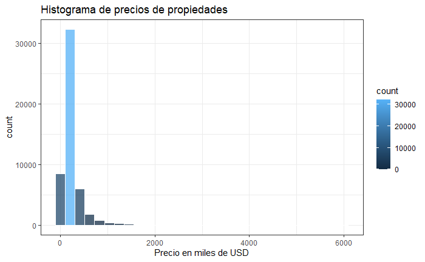

```r
# Armo histograma de precios de las propiedades
ggplot(data = datos_limpios, aes(x = precio_en_miles)) +
  geom_histogram(col = "white", aes( fill = ..count..), alpha = 0.75) +
  labs(title = "Histograma de precios de propiedades") +
  labs(x = "Precio en miles de USD") +
  theme_bw()
```

### Estadisticas descriptivas para la variable precio_en_miles por tipo de propiedad

Se calcularon las principales estadísticas descriptivas de la variable precio por tipo de propiedad como así también la frecuencia de cada una de ellas. Esto ayuda a entender el peso relativo de cada tipo de propiedad en el precio. En este sentido, cabe destacar que la base de datos analizada cuenta con registros que corresponden en un 86.6% a departamentos, un 9.6% a PHs y sólo un 3.7% a casas en venta en Capital Federal.

- Por otro lado, analizando las estadísticas descriptivas por tipo de propiedad se puede observar que, en **promedio**, las casas presentan mayores precios de venta que los departamentos y PHs.
- A priori parece que los precios tienen un comportamiento distinto en función del tipo de propiedad, moviéndose en diferentes rangos. El 75% de los departamentos se venden a precios inferiores a 260 mil dólares (Q3), mientras que en el caso de los PH, ese porcentaje llega a 270 mil y las casas a 490 mil dólares.
- Asimimso, los **desvíos** muestran que existe mayor variabilidad de precios en el caso de las casas, seguida por departamentos.
- Los **mínimos** parecen bajos, en el caso del departamento figura uno de 6 mil dolares, pero habría que ver la relación precio por metro cuadrado para ver si se trata de un valor atípico, un error o simplemente de un terreno pequeño.

```r
# calculo estadisticas descriptivas pero agrupando por tipo de propiedad
datos_limpios %>%
  group_by(property_type) %>%
  summarise(Freq_abs = length(precio_en_miles),
            Freq_rel = round(length(precio_en_miles)/nrow(datos_limpios)*100,2) ,
            Minimo = min(precio_en_miles), Q1 = quantile(precio_en_miles, probs = 0.25),
            Mediana = quantile(precio_en_miles, probs = 0.5),
            Promedio = round(mean(precio_en_miles),0),
            Q3 = quantile(precio_en_miles, probs = 0.75),
            Maximo = max(precio_en_miles),
            Desvio = round(sd(precio_en_miles),0))
```

| property_type | Freq_abs | Freq_rel | Minimo | Q1 | Mediana | Promedio | Q3 | Maximo | Desvio |
| --- | --- | --- | --- | --- | --- | --- | --- | --- | --- |
| Casa | 1913 | 3.76 | 20 | 235 | 330 | 433 | 490 | 5000 | 410 |
| Departamento | 44022 | 86.61 | 6 | 115 | 165 | 247 | 260 | 6000 | 298 |
| PH | 4893 | 9.63 | 32 | 137 | 190 | 219 | 270 | 1500 | 114 |

**Boxplots paralelos de la variable precio por tipo de propiedad**

Complementando los resultados observados del análisis de estadísticos, los boxplots paralelos permiten notar que hay gran presencia de valores atípicos.

Asimismo, acotando la escala del gráfico se puede corroborar lo que se vio en las estadísticas descriptivas previas: que las casas presentan mayores precios y a su vez, mayor variabilidad. En efecto, el 50% central de los datos se mueve en un rango mayor de precios al de los departamentos y PHs. Entre departamentos y PHs, los primeros tendrian menores precios aunque variabilidad similar.

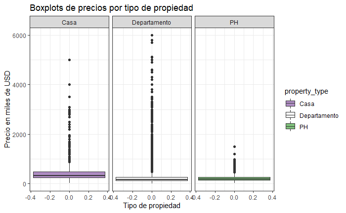

```r
# armo boxplots paralelos segun el tipo de propiedad (casa, dpto o ph)
ggplot(datos_limpios, aes(y = precio_en_miles, group = property_type, fill = property_type )) +
  geom_boxplot() +
  labs(title = "Boxplots de precios por tipo de propiedad")+
  theme(legend.position = 'none') +
  scale_fill_brewer(palette = "PRGn") +
  labs(y = "Precio en miles de USD") +
  labs(x = "Tipo de propiedad") +
  facet_wrap(~ property_type) +
  theme_bw()
```

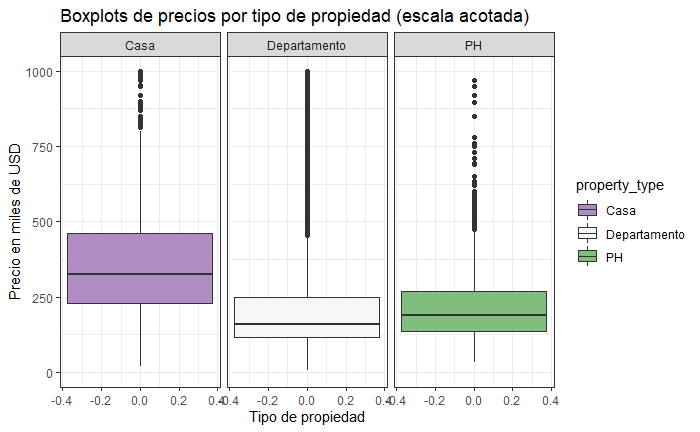

```r
# Acotando la escala del grafico para visualizar mejor el 50% centra de datos
ggplot(datos_limpios, aes(y = precio_en_miles, group = property_type, fill = property_type )) +
  geom_boxplot() +
  labs(title = "Boxplots de precios por tipo de propiedad (escala acotada)")+
  scale_fill_brewer(palette = "PRGn") +
  theme(legend.position = 'none') +
  scale_y_continuous(limits = c(0, 1000)) +
  labs(y = "Precio en miles de USD") +
  labs(x = "Tipo de propiedad") +
  facet_wrap(~ property_type) +
  theme_bw()
```

### Gráfico ggpairs

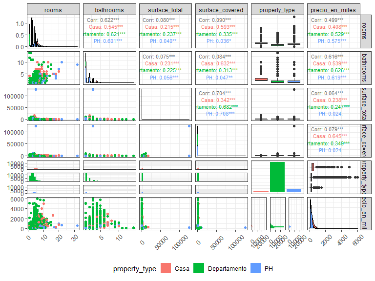

```r
library(GGally)
# graficamos con ggpairs coloreando por property type
# descartando variables no numéricas y el precio para no duplicar la información que ya tenemos en precio_en_miles
ggpairs(datos_limpios %>% select(-c("id", "l3", "price")),
        aes(color = property_type),
        progress = FALSE,
        upper = list(continuous = wrap("cor", size = 3, hjust=0.7)),
        legend = 25) +
  theme_bw() +
  theme(axis.text.x = element_text(angle=45, vjust=0.5), legend.position = "bottom")
```

Respecto de nuestra variable a predecir, el precio en miles, observamos:

- Existe una correlación positiva muy baja con las superficies total y cubierta. Respecto a estas últimas existe una gran diferencia en la correlación según el tipo de propiedad. Lo que no parece razonable porque en general el precio depende de la superficie y asimismo, con una medida más robusta de correlación, verificamos que esta correlación era fuerte. Esto evidencia presencia de outliers.
- Existe una correlación positiva moderada con el número de habitaciones y baños.

## Detección de Outliers

Se van a hacer los análisis para outliers univariados teniendo en cuenta que según los gráficos anteriores parecen existir valores atipicos para la superficie y la cantidad de cuartos.

**Scatterplot de la variable precio_en_miles y superficie_total**

De una primera visualización, parece haber presencia de outliers.

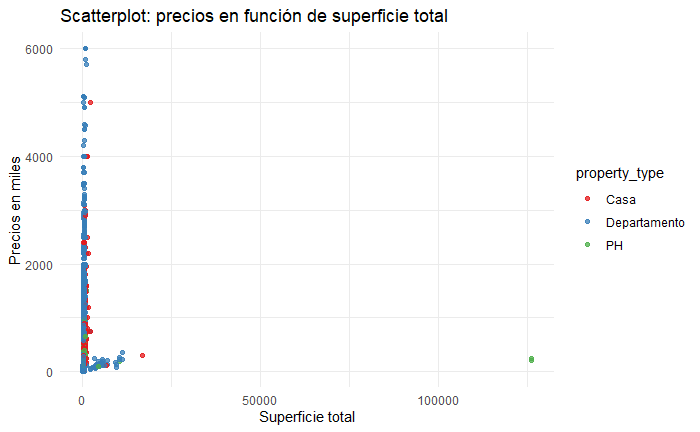

```r
# grafico los precios en funcion superficie para detectar algun outlier visualmente
ggplot(datos_limpios, aes(x = surface_total, y = precio_en_miles, color = property_type)) +
  geom_point(alpha = 0.75) +
  scale_color_brewer(palette = "Set1") +
  theme(legend.position = "none") +
  theme_minimal() +
  labs(y = "Precios en miles", x = "Superficie total") +
  ggtitle("Scatterplot: precios en función de superficie total")
```

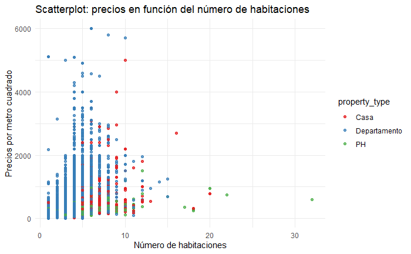

```r
# se grafica adicionalmente la variable rooms para detectar presencia de valores atípicos
ggplot(datos_limpios, aes(x = rooms, y = precio_en_miles, color = property_type)) +
  geom_point(alpha = 0.75) +
  scale_color_brewer(palette = "Set1") +
  theme(legend.position = "none") +
  theme_minimal() +
  labs(y = "Precios por metro cuadrado", x = "Número de habitaciones") +
  ggtitle("Scatterplot: precios en función del número de habitaciones")
```

En particular, se destaca la presencia de un regitro atípico correspondiente a un PH de 126000 metros de superficie por 215 mil dolares y de un registro de un numero de ambientes de 32, también correspondiente a un PH en San Telmo.

Se analizaron asimismo otros datos atípicos, efectuando filtros a dichas variables. En algunos casos se detectaron errores que podrían deberse a errores de carga o de escala de medición. Estos casos se tratarán luego con los métodos de tratamiento de outliers que se describen a continuación. Respecto de las habitaciones/ambientes, no parece haber otro valor atípico que llame precisamente la atención.

```r
# chequeo algunos registros que parecen atípicos
max(datos_limpios$surface_total)
```

```
[1] 126062
```

```r
max(datos_limpios$rooms)
```

```
[1] 32
```

### Tratamiento de outliers

Para detectar presencia de outliers, además de analizar los scatterplot, se definió crear una variable de precio por metro cuadrado ya que, de proceder sólo empleando los precios, se correría el riesgo de eliminar propiedades de precios altos que en realidad corresponden a superficies más amplias y no serían valores atípicos. Por lo que, detectar outliers en base a esta nueva variable es una forma de evitar incurrir en errores de ese estilo.

```r
# armo una nueva variable que sea precios por metro (superficie)
datos_sin_outliers <- datos_limpios %>%
  mutate(pxmt = round(price/surface_total,0))
summary(datos_sin_outliers$pxmt)
```

```
   Min. 1st Qu.  Median    Mean 3rd Qu.    Max.
      2    2157    2656    2801    3235  124683
```

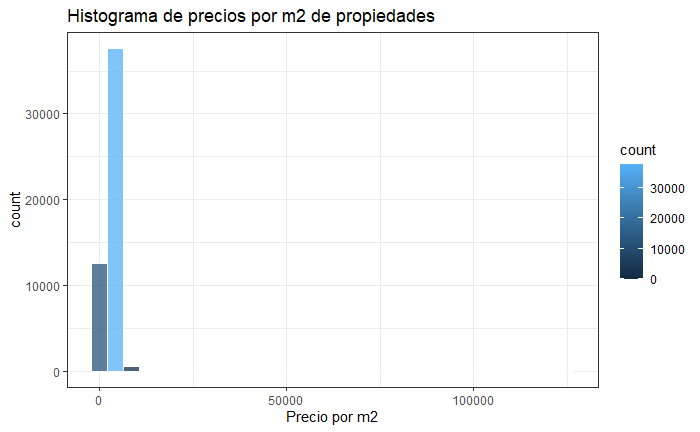

```r
# Armo histograma de precios x metro cuadrado
ggplot(data = datos_sin_outliers, aes(x = pxmt)) +
  geom_histogram(col = "white", aes( fill = ..count..), alpha = 0.75) +
  labs(title = "Histograma de precios por m2 de propiedades") +
  labs(x = "Precio por m2") +
  theme_bw()
```

### Usando 3 desvíos del rango intercuartil para las variables y valor de corte

El filtro de outliers utilizado es una “adaptación” del criterio de Tukey que usualmente usa 1.5 veces la distancia intercuartil. Se optó por adicionar un criterio de valor de corte porque la técnica de desvíos del RI resulta insufiente para detectar outliers a izquierda en una distribución asimétrica a derecha.

Se tomó como valor de corte 750 dólares por metro cuadrado ya que de acuerdo a un relevamento de Evolución histórica del valor del metro cuadrado en CABA - Deptos. 2, 3 ambientes en USD ajustados por inflación, el valor mínimo fue de 783 dolares el metro cuadrado. [Link al blog properati](https://blog.properati.com.ar/el-valor-del-metro-cuadrado-esta-realmente-en-su-pico-historico/)

```r
pxmt_sup = IQR(datos_sin_outliers$pxmt) * 3 + quantile(datos_sin_outliers$pxmt, 0.75)
pxmt_sup
```

```
 75%
6469
```

```r
pxmt_inf = quantile(datos_sin_outliers$pxmt, 0.25) - IQR(datos_sin_outliers$pxmt) * 3
pxmt_inf
```

```
  25%
-1077
```

```r
rooms_sup = IQR(datos_sin_outliers$rooms) * 3 + quantile(datos_sin_outliers$rooms, 0.75)
rooms_sup
```

```
75%
 10
```

```r
rooms_inf = quantile(datos_sin_outliers$rooms, 0.25) - IQR(datos_sin_outliers$rooms) * 3
rooms_inf
```

```
25%
 -4
```

```r
datos_sin_outliers = datos_sin_outliers %>%
  filter(between(pxmt, 750, pxmt_sup), between(rooms, 0, rooms_sup)) # redondeo en 500 el 496.5 y pongo el valor minimo de una casa no puede ser menor a 10 mil
glimpse(datos_sin_outliers)# 49835
```

```
Rows: 49,835
Columns: 10
$ id              <chr> "AfdcsqUSelai1ofCAq2B0Q==", "ESzybdH7YU2uIU1/kHtRGw==", "r~
$ l3              <chr> "Velez Sarsfield", "Nuñez", "Almagro", "Almagro", "Almagro~
$ rooms           <dbl> 3, 1, 1, 1, 1, 1, 1, 1, 1, 1, 1, 1, 1, 1, 1, 3, 1, 1, 2, 1~
$ bathrooms       <dbl> 2, 1, 1, 1, 1, 1, 1, 1, 1, 1, 1, 1, 1, 1, 1, 2, 1, 1, 1, 1~
$ surface_total   <dbl> 95, 44, 40, 49, 40, 40, 40, 49, 40, 23, 40, 40, 32, 40, 36~
$ surface_covered <dbl> 69, 38, 37, 44, 37, 37, 37, 44, 37, 23, 37, 37, 30, 34, 33~
$ price           <dbl> 199900, 147000, 92294, 115000, 77000, 88900, 88798, 110975~
$ property_type   <chr> "Casa", "Departamento", "Departamento", "Departamento", "D~
$ precio_en_miles <dbl> 200, 147, 92, 115, 77, 89, 89, 111, 93, 69, 99, 97, 125, 1~
$ pxmt            <dbl> 2104, 3341, 2307, 2347, 1925, 2222, 2220, 2265, 2324, 3000~
```

```r
nrow(datos_limpios) - nrow(datos_sin_outliers)
```

```
[1] 993
```

Luego de aplicar ambos métodos de eliminación de valores atípicos, se obtuvo un dataset final de 49.835 registros y 10 variables. Es decir, se eliminaron en total 993 registros (menos del 2% del total).

## Se repite analisis exploratorio al dataset sin outliers

A través de las estadísticas descriptivas se puede ver cómo se redujo el **promedio** (de 252 a 234) y el **desvío estándar** (de 293 a 226), mientras la mediana y los cuartiles permanecieron estables. Esto es así por la alta sensibilidad de la media y el desvío a outliers y la robustez de los demás estadísticas frente a valores atípicos. El valor mínimo es mayor (de 6 a 12) y el máximo algo inferior (de 6000 a 5700).

El histograma de precios y los boxplots paralelos según tipo de propiedad para esos precios en miles de dólares no se modificó demasiado, se vuelve a corroborar que las casas presentan en general precios más altos y, a su vez, mayor variabilidad de precios que los deparamientos y PHs.

El correlograma sin outliers permite visualizar mejor la asociación lineal entre las distintas variables numéricas. En particular, se ve más claramente la asociación lineal entre el precio y la superficie al eliminar los valores atípicos de ambas variables, a diferencia de lo que ocurría en el dataset original, que no se percibái por el scatterplot dicho vínculo.

Asimismo, el color de los gráficos permite visualizar comportamientos distintos de las variables según el tipo de propiedad. Esto ya se podía notar en el correlograma previo.

```r
# Tabla de estadisticas descriptivas de la variable precio para el nuevo conjunto de datos sin outliers
datos_sin_outliers %>%
  summarise(Minimo = min(precio_en_miles),
            Q1 = quantile(precio_en_miles, probs = 0.25),
            Mediana = quantile(precio_en_miles, probs = 0.5),
            Promedio = round(mean(precio_en_miles),0),
            Q3 = quantile(precio_en_miles, probs = 0.75),
            Maximo = max(precio_en_miles),
            Desvio = round(sd(precio_en_miles),0))
```

| Minimo | Q1 | Mediana | Promedio | Q3 | Maximo | Desvio |
| --- | --- | --- | --- | --- | --- | --- |
| 12 | 118 | 169 | 234 | 268 | 5700 | 226 |

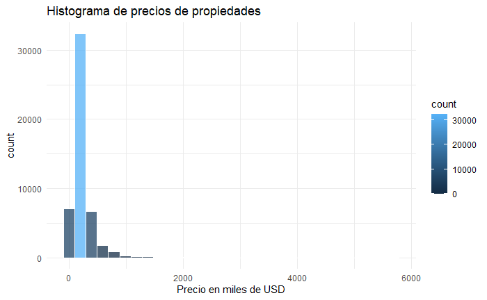

```r
# Armo histograma para ver distribucion de precios en miles del nuevo dataset
ggplot(data = datos_sin_outliers, aes(x = precio_en_miles)) +
  geom_histogram(col = "white", aes( fill = ..count..), alpha = 0.75) +
  labs(title = "Histograma de precios de propiedades") +
  labs(x = "Precio en miles de USD") +
  theme_minimal()
```

```r
# Tabla de estadisticas descriptivas por tipo de propiedad
datos_sin_outliers %>%
  group_by(property_type) %>%
  summarise(Minimo = min(precio_en_miles), Q1 = quantile(precio_en_miles, probs = 0.25), Mediana = quantile(precio_en_miles, probs = 0.5), Promedio = round(mean(precio_en_miles),0), Q3 = quantile(precio_en_miles, probs = 0.75),  Maximo = max(precio_en_miles), Desvio = round(sd(precio_en_miles),0))
```

| property_type | Minimo | Q1 | Mediana | Promedio | Q3 | Maximo | Desvio |
| --- | --- | --- | --- | --- | --- | --- | --- |
| Casa | 62 | 245 | 340 | 437 | 495 | 5000 | 404 |
| Departamento | 12 | 115 | 160 | 228 | 255 | 5700 | 222 |
| PH | 45 | 138 | 190 | 218 | 270 | 1200 | 110 |

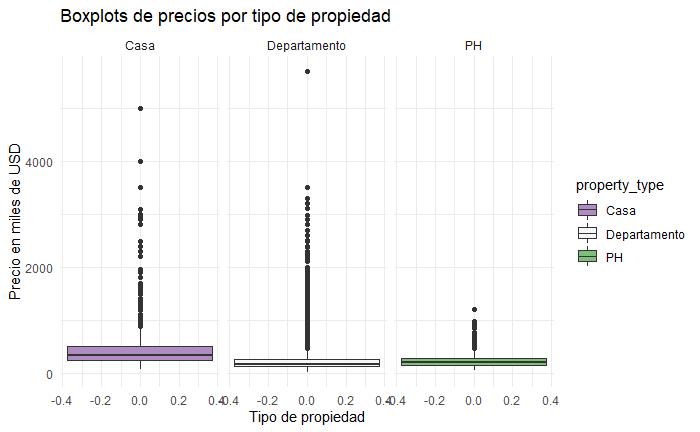

```r
# Armo boxplots paralelos segun el tipo de propiedad (casa, dpto o ph) con el nuevo dataset
ggplot(datos_sin_outliers, aes(y = precio_en_miles, fill = property_type )) +
  geom_boxplot() +
  labs(title = "Boxplots de precios por tipo de propiedad")+
  theme(legend.position = 'none') +
  theme_minimal() +
  scale_fill_brewer(palette = "PRGn") +
  scale_y_continuous() +
  labs(y = "Precio en miles de USD") +
  labs(x = "Tipo de propiedad") +
  facet_wrap(~ property_type)
```

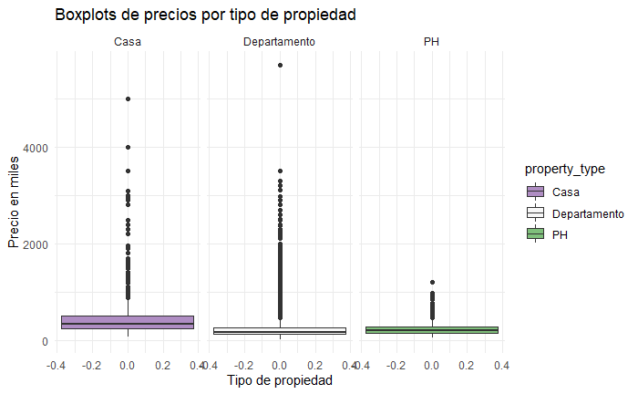

```r
# Armo boxplots paralelos de precios por metro cuadrado segun el tipo de propiedad sin outliers
ggplot(datos_sin_outliers, aes(y = precio_en_miles, fill = property_type )) +
  geom_boxplot() +
  labs(title = "Boxplots de precios por tipo de propiedad") +
  theme(legend.position = 'none') +
  theme_minimal() +
  scale_fill_brewer(palette = "PRGn") +
  scale_y_continuous() +
  labs(y = "Precio en miles") +
  labs(x = "Tipo de propiedad") +
  facet_wrap(~ property_type)
```

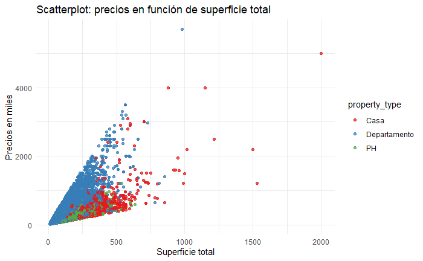

```r
# armo scatterplot de precios en miles en función de superficie total
ggplot(datos_sin_outliers, aes(x = surface_total, y = precio_en_miles, color = property_type)) +
  geom_point(alpha = 0.75) +
  scale_color_brewer(palette = "Set1") +
  theme(legend.position = "none") +
  theme_minimal() +
  labs(y = "Precios en miles", x = "Superficie total") +
  ggtitle("Scatterplot: precios en función de superficie total")
```

Rearmando el histograma de precios por metro sin outliers, se observa mucho más clara la distribución de precios por metro cuadrado, con valores máximos que rondan los 6000 dólares en barrios de los más caros como puerto madero.

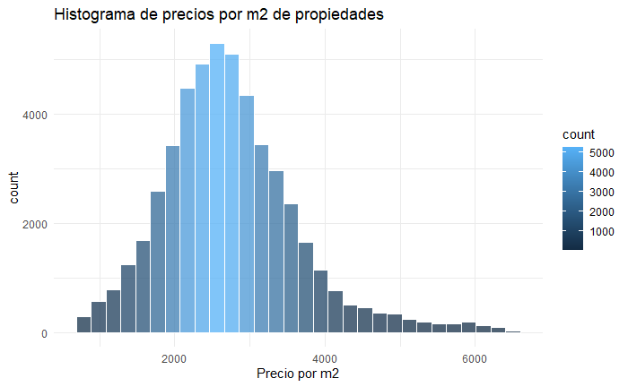

```r
# Armo histograma de precios x metro cuadrado
ggplot(data = datos_sin_outliers, aes(x = pxmt)) +
  geom_histogram(col = "white", aes( fill = ..count..), alpha = 0.75) +
  labs(title = "Histograma de precios por m2 de propiedades") +
  labs(x = "Precio por m2") +
  theme_minimal()
```

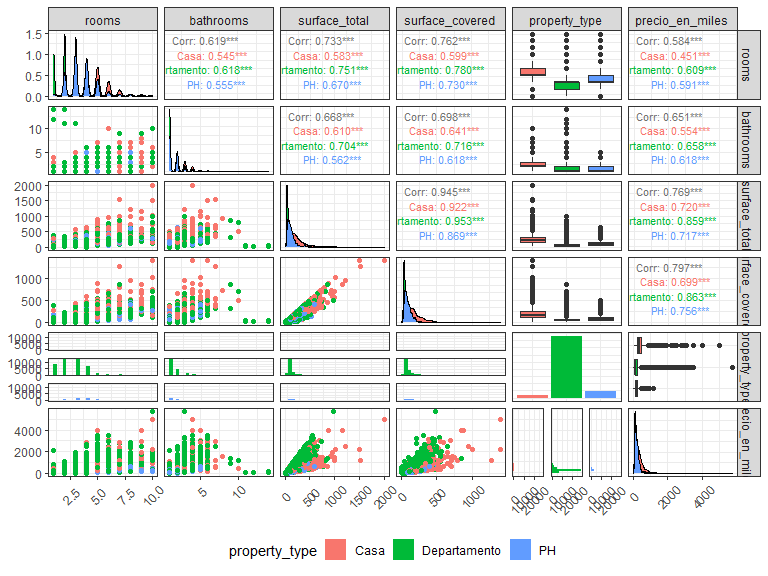

```r
datos_sin_outliers %>%
  # descartando variables no numéricas y el precio para no duplicar la información que ya tenemos en precio_en_miles
  select(-c("id", "l3", "price", "pxmt")) %>%
  ggpairs(., aes(color = property_type), upper = list(continuous = wrap("cor", size = 3, hjust=0.7)), legend = 25, progress = FALSE) +
  theme_bw() +
  theme(axis.text.x = element_text(angle=45, vjust=0.5), legend.position = "bottom")
```

```r
glimpse(datos_sin_outliers)
```

```
Rows: 49,835
Columns: 10
$ id              <chr> "AfdcsqUSelai1ofCAq2B0Q==", "ESzybdH7YU2uIU1/kHtRGw==", "r~
$ l3              <chr> "Velez Sarsfield", "Nuñez", "Almagro", "Almagro", "Almagro~
$ rooms           <dbl> 3, 1, 1, 1, 1, 1, 1, 1, 1, 1, 1, 1, 1, 1, 1, 3, 1, 1, 2, 1~
$ bathrooms       <dbl> 2, 1, 1, 1, 1, 1, 1, 1, 1, 1, 1, 1, 1, 1, 1, 2, 1, 1, 1, 1~
$ surface_total   <dbl> 95, 44, 40, 49, 40, 40, 40, 49, 40, 23, 40, 40, 32, 40, 36~
$ surface_covered <dbl> 69, 38, 37, 44, 37, 37, 37, 44, 37, 23, 37, 37, 30, 34, 33~
$ price           <dbl> 199900, 147000, 92294, 115000, 77000, 88900, 88798, 110975~
$ property_type   <chr> "Casa", "Departamento", "Departamento", "Departamento", "D~
$ precio_en_miles <dbl> 200, 147, 92, 115, 77, 89, 89, 111, 93, 69, 99, 97, 125, 1~
$ pxmt            <dbl> 2104, 3341, 2307, 2347, 1925, 2222, 2220, 2265, 2324, 3000~
```

```r
write.csv(datos_sin_outliers %>% select(-c(pxmt)), file = "properati_preprocesado.csv", row.names=FALSE)
write_csv(datos_sin_outliers %>% select(-c(pxmt)), file = "properati_preprocesado_.csv")
```